# Investigation of Exponential Distribution and Comparison with Central Limit Theorem

Brett A. Ochs

February 28, 2016

```r
library(ggplot2)
```

## Overview

This Statistical Inference Course Project will investigate the exponential distribution in R and compare it with the Central Limit Theorem. We will use lambda (0.2) as the rate parameter. The mean of exponential distribution is 1/lambda and the standard deviation is also 1/lambda. We will investigate the distribution of averages of 40 exponentials using a thousand simulations.

First we will set some variables for number of simulations and sample size as well theoretical variables such as means, standard deviation, and variance.

```r
## Set variables based on homework guidance
lambda <- 0.2
num.exp <- 40
num.sim <- 1000

## Theoretical mean and standard deviation of exponential distribution
mean.exp.dist <- 1/lambda
sd.exp.dist <- 1/lambda
sd.exp.var <- sd.exp.dist^2/num.exp
```

## Simulations

Next we will run 1000 simulations of 40 samples of exponentials. We use the rexp() function in R stats package to generate 1000 simulations with number of observations set to 40 and lambda=0.2. We save this into a data frame for use in graphics and summary statistics later.

```r
## Generate 1000 simulations of 40 exponential distributions
sim.1000 <- data.frame(sim.40=sapply(1:num.sim, function(exp.sim){
    mean(rexp(num.exp, lambda))}))
summary(sim.1000)
```

```
##      sim.40
##  Min.   :2.590
##  1st Qu.:4.519
##  Median :5.014
##  Mean   :5.041
##  3rd Qu.:5.528
##  Max.   :8.401
```

## Sample Mean versus Theoretical Mean

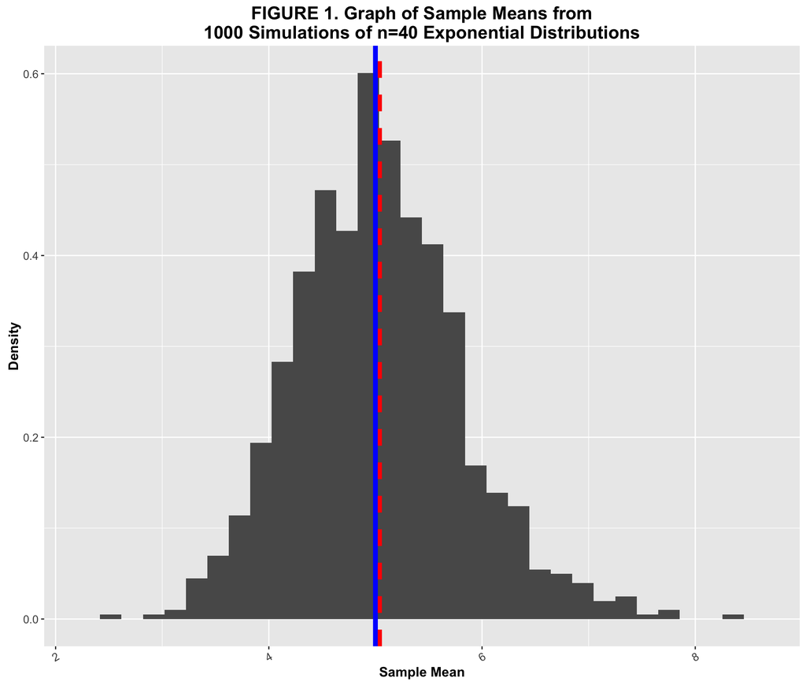

```r
## Calculate sample mean from data frame containing simulation results
sample.mean <- mean(sim.1000$sim.40)
## Graph the simulated means along with theoretical distribution
bw <- diff(range(sim.1000$sim.40)) / (2 * IQR(sim.1000$sim.40) / length(sim.1000$sim.40)^(1/3))
ggplot(sim.1000, aes(x=round(sim.40, digits=1))) + geom_histogram(aes(y=..density..), bins=bw) +
    geom_vline(xintercept=mean.exp.dist, color="blue", lwd=2) +
    geom_vline(xintercept=sample.mean, color="red", lwd=1.75, linetype="dashed") +
    labs(title="FIGURE 1. Graph of Sample Means from\n1000 Simulations of n=40 Exponential Distributions",
         x="Sample Mean", y="Density") +
    theme(axis.text.x=element_text(angle=30, vjust=0.5, size=10),
          legend.position="none",
          axis.text.y=element_text(size=10),
          axis.title=element_text(size=12, face="bold"),
          plot.title=element_text(size=16, face="bold"))
```

```r
## Run ttest on simulation mean to determine confidence interval to compare theoretical mean
t.test(sim.1000$sim.40)
```

```
##
##  One Sample t-test
##
## data:  sim.1000$sim.40
## t = 205.1, df = 999, p-value < 2.2e-16
## alternative hypothesis: true mean is not equal to 0
## 95 percent confidence interval:
##  4.993012 5.089476
## sample estimates:
## mean of x
##  5.041244
```

If we look at the graph of the 1000 simulations of exponential distributions we find the sample mean (red dashed line) is **5.04** which is very close to the theoretical mean (blue solid line) of **5** with difference of only **-0.04**.

We can also look at the 95% confidence interval of the sample mean using t.test() in R. We find that this confidence interval ranges from **4.99** to **5.09**, and the theoretical mean of **5** falls within this CI. We can then fail to reject the null hypothesis that the sample mean and theoretical mean are the same.

## Sample Variance versus Theoretical Variance:

```r
sample.variance <- var(sim.1000$sim.40)
```

If we calculate the sample variance of **0.6** from the 1000 simulations and find it very close to the theoretical variance of **0.62**.

## Distribution:

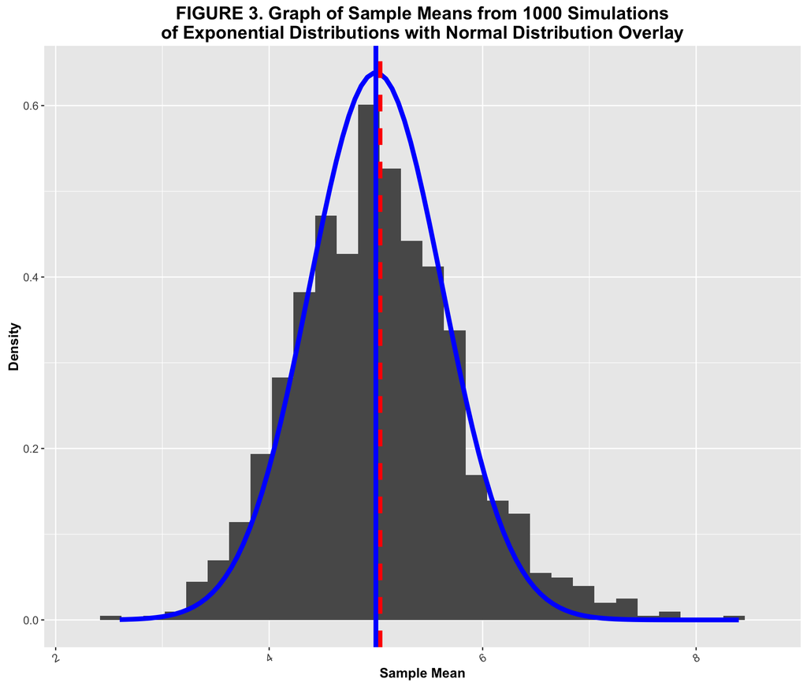

```r
## Graph the simulated means along with theoretical distribution
ggplot(sim.1000, aes(x=round(sim.40, digits=1))) + geom_histogram(aes(y=..density..), bins=bw) +
    stat_function(fun=dnorm, args=list(mean=mean.exp.dist, sd=sd.exp.var), lwd=2, col="blue") +
    geom_vline(xintercept=mean.exp.dist, color="blue", lwd=2) +
    geom_vline(xintercept=sample.mean, color="red", lwd=1.75, linetype="dashed") +
    labs(title="FIGURE 3. Graph of Sample Means from 1000 Simulations\nof Exponential Distributions with Normal Distribution Overlay",
         x="Sample Mean", y="Density") +
    theme(axis.text.x=element_text(angle=30, vjust=0.5, size=10),
          legend.position="none",
          axis.text.y=element_text(size=10),
          axis.title=element_text(size=12, face="bold"),
          plot.title=element_text(size=16, face="bold"))
```